# Assigment1_task1_Mireia

Mireia Valle

05/02/2020

# **Task 1 (individual): Data wrangling & visualization (showshoe hares)**

For Task 1 you will wrangle, then create a final visualization and summary table, of physical characteristics for snowshoe hares observed in Bonanza Creek Experimental Forest.

**Data**: download showshoe_data.csv [here](https://drive.google.com/file/d/1d4LGOzyXHuQztwVQjU8IdmVvzRACVps4/view?usp=sharing)

**Information & metadata**: click [here](https://portal.lternet.edu/nis/metadataviewer?packageid=knb-lter-bnz.55.22)

**Study citation**: [Kielland K., F. S. Chapin, R. W. Ruess. 2017. Snowshoe hare physical data in Bonanza Creek Experimental Forest: 1999-Present. Environmental Data Initiative](https://doi.org/10.6073/pasta/03dce4856d79b91557d8e6ce2cbcdc14).

You get to decide what variables and summary statistics to visualize.

Here’s what you should prepare:

A single polished HTML (knitted from .Rmd), planning that this might be a post/project you’d include on your personal blogdown site, that includes at least:

1. A useful descriptive introductory summary (3 - 4 sentences) of what’s contained in the project

2. Image(s), with captions and necessary citation(s), of showshoe hares and/or a map of the study area

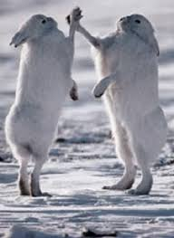

snowshoe hares

3. All of your organized and well-annotated code (with warnings/messages hidden) used to create at least:
- One finalized graph about the Bonanza Creek snowshoe hare population (you pick which variables, how you want to wrangle it beforehand, and which type of visual to create - but make sure it is beautifully finalized)

## Load libraries

```r
library(here) #constructs paths to your project's files
library(tidyverse) #data wrangling
library(kableExtra) #to make html tables
library(skimr) #for summarizing the data
library(lubridate)#change dates
library(naniar)#to explore missing values
library(VIM)#to explore missing values
```

## Loading the data

```r
snowshoes <- read_csv("task1/showshoe_lter.csv")
#snowshoes <- read_csv(here("task1", "showshoe_lter.csv"))
```

## Exploring and wrangling the data

Summarizing

```r
head(snowshoes)
```

```
## # A tibble: 6 x 14
##   date  time  grid  trap  l_ear r_ear sex   age   weight hindft notes b_key
##   <chr> <lgl> <chr> <chr> <chr> <dbl> <chr> <chr>  <dbl>  <dbl> <chr> <dbl>
## 1 11/2~ NA    bonr~ 1A    414D~    NA <NA>  <NA>    1370    160 <NA>    917
## 2 11/2~ NA    bonr~ 2C    414D~    NA M     <NA>    1430     NA <NA>    936
## 3 11/2~ NA    bonr~ 2D    414D~    NA M     <NA>    1430     NA <NA>    921
## 4 11/2~ NA    bonr~ 2E    414D~    NA <NA>  <NA>    1490    135 <NA>    931
## 5 11/2~ NA    bonr~ 3B    414D~    NA <NA>  <NA>    1710    150 <NA>    933
## 6 11/2~ NA    bonr~ 3D    414D~    NA F     <NA>    1890    145 <NA>    926
## # ... with 2 more variables: session_id <dbl>, study <chr>
```

```r
summary(snowshoes)
```

```
##      date             time             grid               trap
##  Length:3380        Mode:logical   Length:3380        Length:3380
##  Class :character   NA's:3380      Class :character   Class :character
##  Mode  :character                  Mode  :character   Mode  :character
##
##
##
##
##     l_ear               r_ear          sex                age
##  Length:3380        Min.   :  69   Length:3380        Length:3380
##  Class :character   1st Qu.:1008   Class :character   Class :character
##  Mode  :character   Median :1863   Mode  :character   Mode  :character
##                     Mean   :1614
##                     3rd Qu.:2166
##                     Max.   :2500
##                     NA's   :928
##      weight         hindft         notes               b_key
##  Min.   :   0   Min.   : 60.0   Length:3380        Min.   :   1.0
##  1st Qu.:1180   1st Qu.:128.0   Class :character   1st Qu.: 235.0
##  Median :1400   Median :135.0   Mode  :character   Median : 464.0
##  Mean   :1346   Mean   :130.9                      Mean   : 500.6
##  3rd Qu.:1580   3rd Qu.:140.0                      3rd Qu.: 755.0
##  Max.   :2365   Max.   :160.0                      Max.   :1034.0
##  NA's   :535    NA's   :1747                       NA's   :47
##    session_id        study
##  Min.   :  1.00   Length:3380
##  1st Qu.: 22.00   Class :character
##  Median : 55.00   Mode  :character
##  Mean   : 53.23
##  3rd Qu.: 82.00
##  Max.   :113.00
##
```

```r
unique(snowshoes$grid)
```

```
## [1] "bonrip" "bonbs"  "Bonbs"  "bonmat"
```

```r
unique(snowshoes$sex)
```

```
##  [1] NA   "M"  "F"  "?"  "F?" "M?" "pf" "m"  "f"  "f?" "m?"
```

```r
skim(snowshoes)
```

Data summary

| Name | snowshoes |
| --- | --- |
| Number of rows | 3380 |
| Number of columns | 14 |
| _______________________ |  |
| Column type frequency: |  |
| character | 8 |
| logical | 1 |
| numeric | 5 |
| ________________________ |  |
| Group variables | None |

**Variable type: character**

| skim_variable | n_missing | complete_rate | min | max | empty | n_unique | whitespace |
| --- | --- | --- | --- | --- | --- | --- | --- |
| date | 0 | 1.00 | 6 | 8 | 0 | 256 | 0 |
| grid | 0 | 1.00 | 5 | 6 | 0 | 4 | 0 |
| trap | 12 | 1.00 | 2 | 3 | 0 | 112 | 0 |
| l_ear | 48 | 0.99 | 2 | 10 | 0 | 1020 | 0 |
| sex | 352 | 0.90 | 1 | 2 | 0 | 10 | 0 |
| age | 2111 | 0.38 | 1 | 9 | 0 | 30 | 0 |
| notes | 3137 | 0.07 | 4 | 163 | 0 | 117 | 0 |
| study | 163 | 0.95 | 6 | 16 | 0 | 4 | 0 |

**Variable type: logical**

| skim_variable | n_missing | complete_rate | mean | count |
| --- | --- | --- | --- | --- |
| time | 3380 | 0 | NaN | : |

**Variable type: numeric**

| skim_variable | n_missing | complete_rate | mean | sd | p0 | p25 | p50 | p75 | p100 | hist |
| --- | --- | --- | --- | --- | --- | --- | --- | --- | --- | --- |
| r_ear | 928 | 0.73 | 1613.64 | 695.96 | 69 | 1007.5 | 1863 | 2166 | 2500 | ▂▃▂▆▇ |
| weight | 535 | 0.84 | 1346.08 | 345.16 | 0 | 1180.0 | 1400 | 1580 | 2365 | ▁▂▇▇▁ |
| hindft | 1747 | 0.48 | 130.87 | 16.16 | 60 | 128.0 | 135 | 140 | 160 | ▁▁▂▇▃ |
| b_key | 47 | 0.99 | 500.64 | 299.42 | 1 | 235.0 | 464 | 755 | 1034 | ▇▇▅▆▆ |
| session_id | 0 | 1.00 | 53.23 | 33.17 | 1 | 22.0 | 55 | 82 | 113 | ▇▃▆▇▅ |

```r
snowshoes_clean <- snowshoes %>%
    mutate(
      grid = str_to_lower(grid),
      sex = str_to_lower(sex))
```

2. convert `date` column to yr_mo_day and create new column with year with `lubridate`

```r
snowshoes_clean_date <- snowshoes_clean %>%
  mutate(yr_mo_day = lubridate::parse_date_time(date, "%m/%d/%y")) %>%
  mutate(year = year(yr_mo_day))
```

Exploring the results

```r
unique(snowshoes_clean_date$grid)
```

```
## [1] "bonrip" "bonbs"  "bonmat"
```

```r
unique(snowshoes_clean_date$sex)
```

```
## [1] NA   "m"  "f"  "?"  "f?" "m?" "pf"
```

3. convert `grid` column to species

```r
snowshoes_clean_species <- snowshoes_clean_date %>%
  mutate(species = "Lepus americanus")
```

Selecting only f and m sex classes

```r
snowshoes_clean_sex <- snowshoes_clean_species %>%
    filter(sex == "f" | sex == "m")
```

Exploring the results

```r
unique(snowshoes_clean_sex$sex)
```

```
## [1] "m" "f"
```

Exploring NA’s using naniar::gg_miss_var()

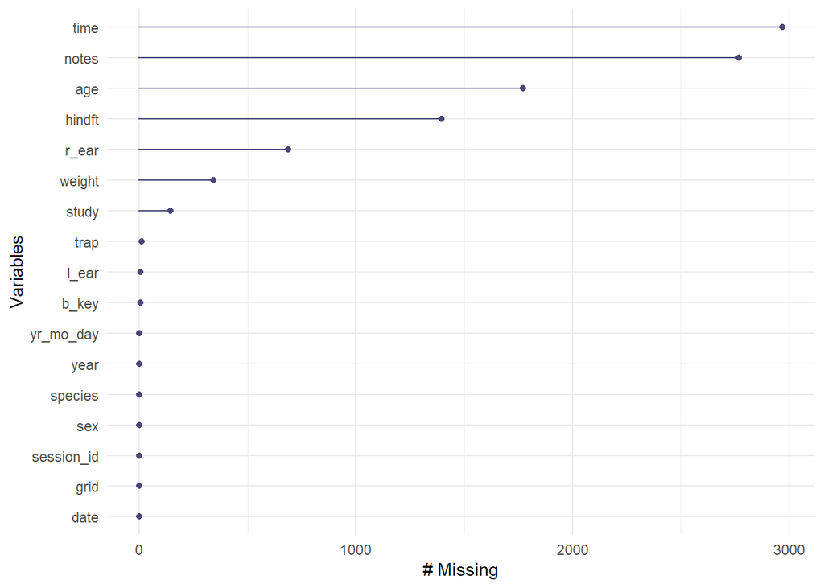

```r
gg_miss_var(snowshoes_clean_sex)
```

Use tidyr::drop_na() to keep complete cases

```r
snowshoes_final <- snowshoes_clean_sex %>%
  drop_na(weight)
```

Select columns that we want to keep for visualization

```r
snowshoes_final <- snowshoes_final %>%
  select(sex, weight, date, year)
```

## Create new data for visualization

```r
snowshoes_count <- snowshoes_final %>%
  group_by(year, sex) %>%
  summarize(n = n())
```

## Visualizing

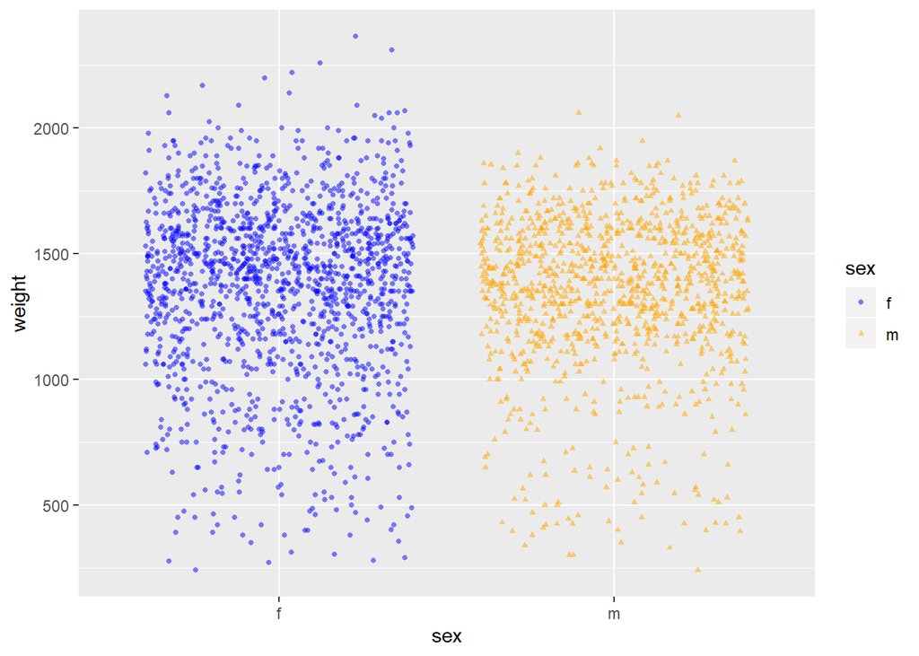

```r
ggplot(snowshoes_final, aes(x = sex, y = weight)) +
  geom_jitter(size = 1,
              alpha = 0.5,
              aes(color = sex,
                  pch = sex)) +
    scale_color_manual(values = c("blue","orange"))
```

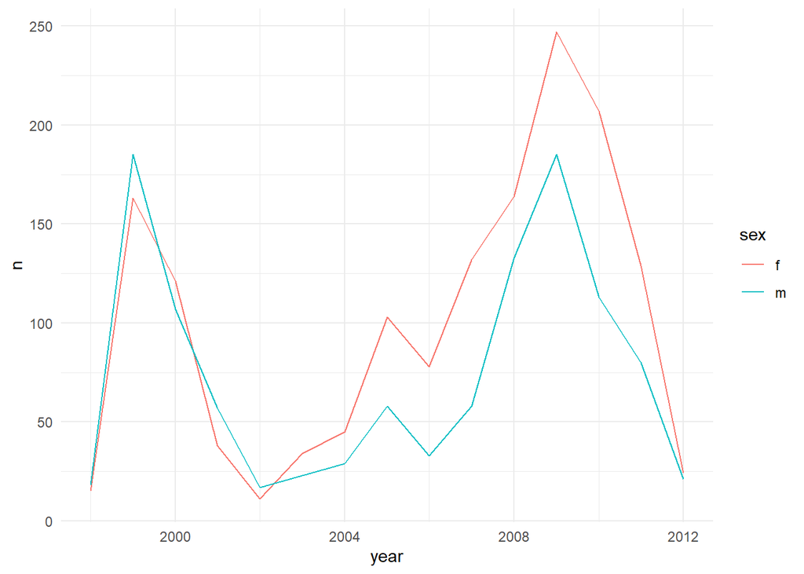

```r
snowshoes_count_gg <- ggplot(data = snowshoes_count, aes(x = year, y = n, group = sex)) +
  geom_line(aes(color = sex)) +
  theme_minimal()

snowshoes_count_gg
```

```r
#kable(state_table) %>%
#  kable_styling(bootstrap_options = "striped",
#                full_width = FALSE) %>%
#  add_header_above(c("", "2015 US commercial fisheries - top 5 states by value" = 2))
```

4. Make sure that both your figure and table appear in your final knitted document, each with a useful caption. Include text associated with each to help the audience understand and interpret the results.

## Sync with GitHub remote

Stage, commit, (pull), and push your updates to GitHub for safe storage & sharing. Check to make sure that the changes have been stored.

## End Part 1!